# Exploration des données

Myriam Trottier-Paquet

2023-09-13

# Contexte

Dans un contexte de changements globaux, de nombreux stresseurs (conditions climatiques extrêmes, dégradation de l’habitat, dérangement humain, pollution) sont susceptibles d’affecter profondément le comportement, la reproduction et la survie des animaux. Si la migration des oiseaux correspond à une réponse adaptative face à de fortes variations saisonnières, celle-ci pourraient être altérée du fait de l’augmentation de multiples stresseurs. Les glucocorticoïdes, ou « hormones de stress » vont varier au niveau de l’organisme en fonction de ces contraintes. La manipulation expérimentale des niveaux de glucocorticoïdes permet de comprendre comment le stress affecte les traits phénotypiques et les décisions comportementales. À l’heure actuelle, il n’existe aucune méthodologie connue pour induire un stress chronique *In natura*.

# Objectifs et hypothèses

L’objectif est de développer une méthodologie pour simuler un stress chronique à l’aide de pompes à diffusion à débit programmable fixées sur les plumes et reliées à un cathéter placé en sous-cutané qui, si elle est validée, pourra être utilisée sur des oies sauvages capturées en migration. Le premier objectif est méthodologique : valider la procédure de fixation des pompes en externe, avec un cathéter sous-cutané. Le second objectif est de simuler un stress chronique sur 5 jours par la diffusion d’ACTH par les pompes.

## Hypothèses

L’administration d’une dose croissante d’ACTH par la méthodologie des pompes à diffusion à débit programmable fixées sur les plumes et reliées à un cathéter placé en sous-cutané peut maintenir la corticostérone à un niveau élevé pendant une période prolongée et entraîner des effets négatifs sur la prise alimentaire et l’engraissement.

Prédiction 1. L’amélioration de la méthode de fixation des pompes peut permettre aux pompes de demeurer en place et fonctionnelles (la solution administrée par la pompe parvient dans l’organisme et est excrétée par les fèces) pour toute la durée de l’expérimentation.

Prédiction 2. Pendant le traitement expérimental, le niveau de corticostérone dans l’organisme devrait demeurer à un niveau élevé, l’allocation de temps au différentes activités et le patron d’engraissement des oies devrait aussi être modifié : les oies devraient passer moins de temps à s’alimenter et perdre de la masse pendant la phase test du traitement par rapport à la phase contrôle.

# Le traitement expérimental

```r
data.frame(Stage=c(0:10),
           Phase=c("Repos", "Test", "Test", "Test", "Test", "Test", "Contrôle", "Contrôle", "Contrôle", "Contrôle", "Contrôle"),
           Dose=c("0", "0,01", "0,02","0,03","0,05","0,07", "0", "0", "0", "0", "0")) %>%
  as_tibble() %>%
    knitr::kable(col.names = c("Jours", "Phase", "Dose d'ACTH administrée (en mg/kg/jour)"),
               align = "ccc",
               caption = "Dosage quotidien",
               format = "simple")
```

Dosage quotidien

| Jours | Phase | Dose d’ACTH administrée (en mg/kg/jour) |
| --- | --- | --- |
| 0 | Repos | 0 |
| 1 | Test | 0,01 |
| 2 | Test | 0,02 |
| 3 | Test | 0,03 |
| 4 | Test | 0,05 |
| 5 | Test | 0,07 |
| 6 | Contrôle | 0 |
| 7 | Contrôle | 0 |
| 8 | Contrôle | 0 |
| 9 | Contrôle | 0 |
| 10 | Contrôle | 0 |

# Variables

Variables indépendantes:

- Espèce: catégorique 2 niveaux (bernache du Canada, Oie des neiges)
- Sexe: catégorique 2 niveaux (mâle, femelle)
- Âge: catégorique 3 niveaux (juvénile, adulte, inconnu)
- Individu (10 ID)
- Masse avant l’expérience (en g): numérique continue
- Longueur du tarse (en mm): numérique continue
- Longueur de la tête (en mm): numérique continue
- Période d’expérimentation : catégorique à 2 niveaux (1, 2) (confondue avec l’effet de l’espèce)
- Dosage d’ACTH administré (en mg/kg/jour): catégorique ordinale à 6 niveaux (0, 0.01, 0.02, 0.03, 0.05, 0.07)
- Phase du traitement: catégorique à 2 niveaux (test, contrôle)

# Exploration des données

```r
cort <- readxl::read_xlsx("../data/CORT_zoo.xlsx",
                              sheet = 1,
                              col_names = T,
                              na = c("-", ""))


#quick overview
glimpse(cort)
```

```
## Rows: 89
## Columns: 7
## $ sample_id     <chr> "3 bleu", "4 bleu", "5 bleu", "6 bleu", "7 bleu", "8 ble…
## $ cort          <dbl> 144.44001, 136.83301, 330.56429, 175.22691, 136.53197, 1…
## $ date          <dttm> 2022-04-07, 2022-04-12, 2022-04-18, 2022-04-18, 2022-04…
## $ species       <chr> "Canada Goose", "Canada Goose", "Snow Goose", "Snow Goos…
## $ individual_id <chr> "B27", "B42", "O17", "O18", "O11", "O07", "O09", "O18", …
## $ mass          <dbl> 0.1068, 0.1000, 0.1001, 0.1001, 0.1000, 0.1023, 0.1005, …
## $ process_date  <dttm> 2022-12-14, 2022-12-14, 2022-12-14, 2022-12-14, 2022-12…
```

```r
head(cort) ;tail(cort)
```

```
## # A tibble: 6 × 7
##   sample_id  cort date                species      individual_id  mass
##   <chr>     <dbl> <dttm>              <chr>        <chr>         <dbl>
## 1 3 bleu     144. 2022-04-07 00:00:00 Canada Goose B27           0.107
## 2 4 bleu     137. 2022-04-12 00:00:00 Canada Goose B42           0.1
## 3 5 bleu     331. 2022-04-18 00:00:00 Snow Goose   O17           0.100
## 4 6 bleu     175. 2022-04-18 00:00:00 Snow Goose   O18           0.100
## 5 7 bleu     137. 2022-04-16 00:00:00 Snow Goose   O11           0.1
## 6 8 bleu     153. 2022-04-17 00:00:00 Snow Goose   O07           0.102
## # ℹ 1 more variable: process_date <dttm>
```

```
## # A tibble: 6 × 7
##   sample_id  cort date                species      individual_id   mass
##   <chr>     <dbl> <dttm>              <chr>        <chr>          <dbl>
## 1 37 vert    110. 2022-04-08 00:00:00 Canada Goose B31           0.100
## 2 38 vert    162. 2022-04-07 00:00:00 Canada Goose B28           0.101
## 3 39 vert    200. 2022-04-21 00:00:00 Snow Goose   O29           0.100
## 4 40 vert    204. 2022-04-21 00:00:00 Snow Goose   O27           0.0999
## 5 41 vert    355. 2022-04-22 00:00:00 Snow Goose   O32           0.1
## 6 42 vert    117. 2022-04-23 00:00:00 Snow Goose   O36           0.100
## # ℹ 1 more variable: process_date <dttm>
```

```r
summary(cort)
```

```
##   sample_id              cort             date
##  Length:89          Min.   : 34.02   Min.   :2022-04-04 00:00:00.00
##  Class :character   1st Qu.:102.52   1st Qu.:2022-04-06 00:00:00.00
##  Mode  :character   Median :133.89   Median :2022-04-16 00:00:00.00
##                     Mean   :152.29   Mean   :2022-04-14 00:32:21.56
##                     3rd Qu.:198.90   3rd Qu.:2022-04-21 00:00:00.00
##                     Max.   :355.05   Max.   :2022-04-26 00:00:00.00
##    species          individual_id           mass
##  Length:89          Length:89          Min.   :0.0999
##  Class :character   Class :character   1st Qu.:0.1000
##  Mode  :character   Mode  :character   Median :0.1002
##                                        Mean   :0.1003
##                                        3rd Qu.:0.1004
##                                        Max.   :0.1068
##   process_date
##  Min.   :2022-12-14 00:00:00.00
##  1st Qu.:2022-12-19 00:00:00.00
##  Median :2022-12-21 00:00:00.00
##  Mean   :2022-12-19 21:50:33.71
##  3rd Qu.:2022-12-21 00:00:00.00
##  Max.   :2022-12-22 00:00:00.00
```

```r
dim(cort)
```

```
## [1] 89  7
```

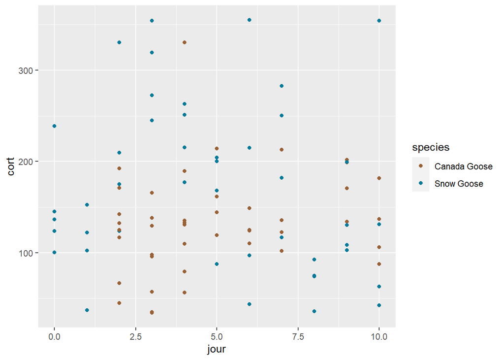

```r
cort_date_cago<-ggplot(subset(cort, species=="Canada Goose"), aes(date, cort))+geom_point()+geom_smooth()+ggtitle("Canada Goose") +
  annotate("rect", xmin = as.POSIXct("2022-04-02 10:00:00.00"), xmax = as.POSIXct("2022-04-07 06:00:00.00"), ymin = 30, ymax = 360,  colour="darkgreen" ,fill = "darkgreen", alpha=.3)+
  annotate("rect", xmin = as.POSIXct("2022-04-07 10:00:00.00"), xmax = as.POSIXct("2022-04-12 06:00:00.00"), ymin = 30, ymax = 360,  colour="black",  fill = "black", alpha=.3)+
  annotate("rect", xmin = as.POSIXct("2022-04-01 10:00:00.00"), xmax = as.POSIXct("2022-04-02 06:00:00.00"), ymin = 30, ymax = 360,  colour="white",  fill = "white", alpha=.8)
cort_date_sngo<-ggplot(subset(cort, species=="Snow Goose"), aes(date, cort))+geom_point()+geom_smooth()+ggtitle("Snow Goose")+ annotate("rect",
    xmin = as.POSIXct("2022-04-16 10:00:00.00"), xmax = as.POSIXct("2022-04-21 06:00:00.00"), ymin = 25, ymax = 365,  colour="darkgreen",  fill = "darkgreen", alpha=.3)+ annotate("rect",
    xmin = as.POSIXct("2022-04-21 10:00:00.00"), xmax = as.POSIXct("2022-04-26 06:00:00.00"), ymin = 25, ymax = 365,  colour="black",  fill = "black", alpha=.3)+
  annotate("rect", xmin = as.POSIXct("2022-04-15 10:00:00.00"), xmax = as.POSIXct("2022-04-16 06:00:00.00"), ymin = 25, ymax = 365,  colour="white",  fill = "white", alpha=.5)

cort2 <- cort %>%
  mutate(
    species = ifelse(species == "snow Goose", "Snow Goose", species),
    date_chir = ifelse(species == "Canada Goose", ymd("2022-04-02"), ymd("2022-04-16")),
    date = ymd(date),  # Parse date as Date
    jour = as.numeric(round(date - date_chir)),
    phase = case_when(
      jour == 0 ~ "recuperation",
      jour > 0 & jour < 6 ~ "test",
      jour >= 6 ~ "controle"
    ),
    phase = factor(phase, levels=c("recuperation", "test", "controle")),
    dose = case_when(
      jour == 1 ~ 0.01,
      jour == 2 ~ 0.02,
      jour == 3 ~ 0.03,
      jour == 4 ~ 0.05,
      jour == 5 ~ 0.07,
      TRUE ~ 0
    )
  )

#quick plot

ggplot(cort2)+geom_point(aes(jour, cort, colour=species))+scale_color_manual(values=c("#996035FF", "#007A99FF"))
```

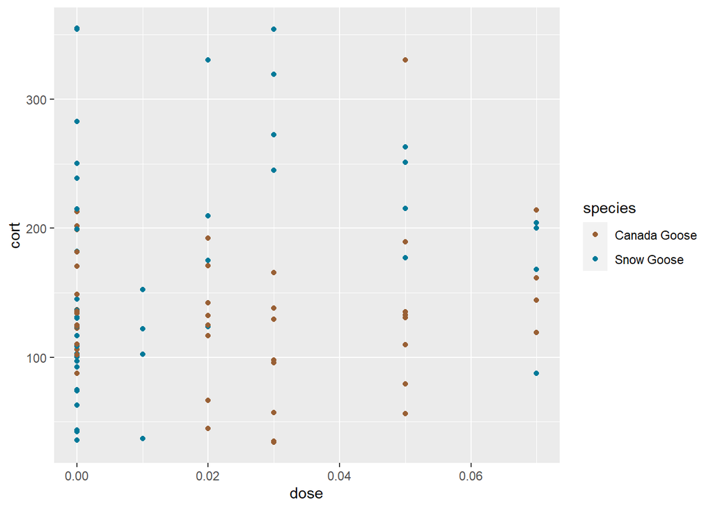

```r
ggplot(cort2)+geom_point(aes(dose, cort, colour=species))+scale_color_manual(values=c("#996035FF", "#007A99FF"))
```

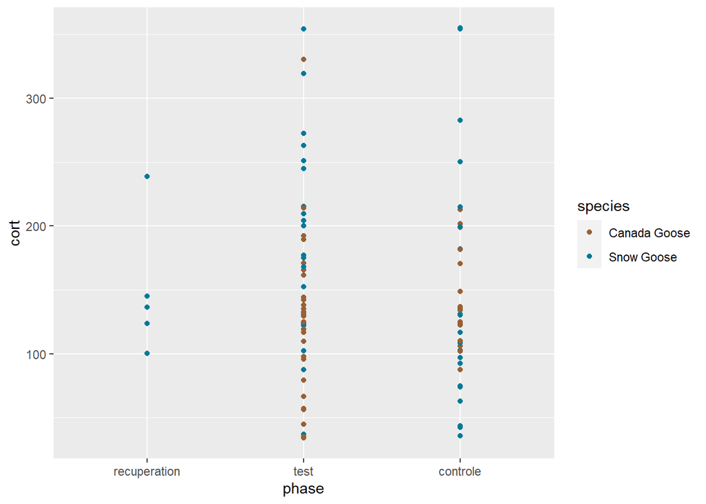

```r
ggplot(cort2)+geom_point(aes(phase, cort, colour=species))+scale_color_manual(values=c("#996035FF", "#007A99FF"))
```

No feces were collected on day 0 and 1 for Canada goose. We have a few high value (>300) for the corticosterone assay, but nothing seems out of range, no outliers.

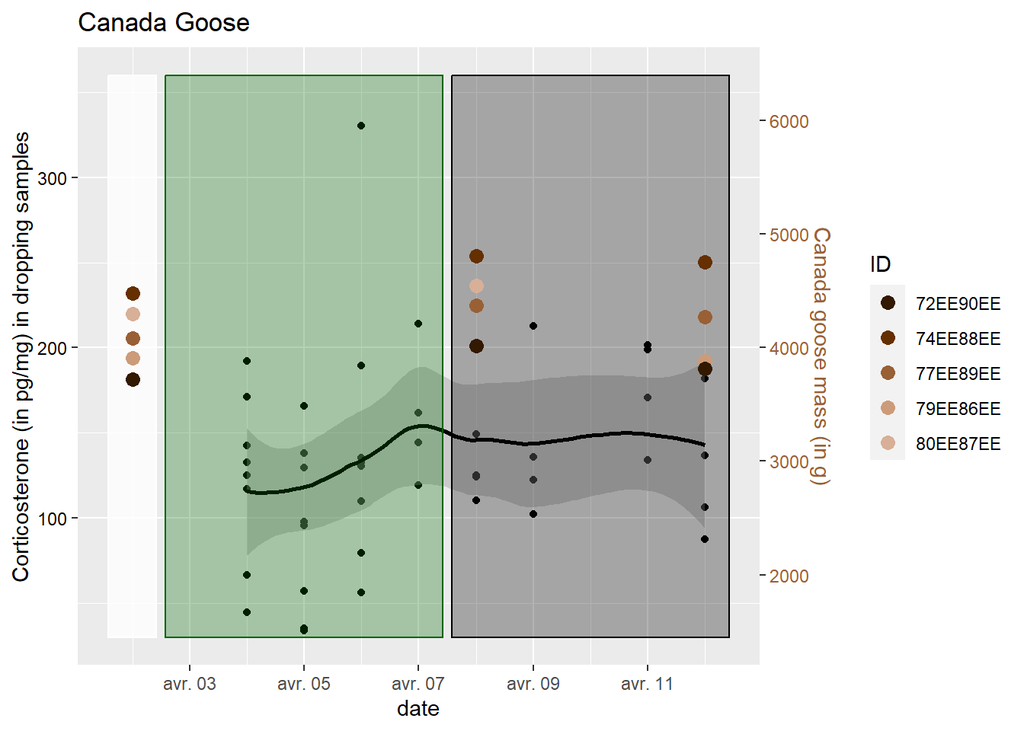

```r
zoo <- readxl::read_xlsx("../data/Zoo2022.xlsx",
                              sheet = 1,
                              col_names = T,
                              na = c("-", ""))

chir <- read.delim2("../data/CHIR.txt",header=TRUE,sep = "\t")

#Plots
CAGO<-subset(zoo, Sp=="CAGO"& Date >= "2022-04-01" & Date <= "2022-04-12")
SNGO<-subset(zoo, Sp=="SNGO"& Date >= "2022-04-15")
plot_cago<-ggplot(subset(cort, species=="Canada Goose"), aes(date, cort))+ scale_y_continuous(name="Corticosterone (in pg/mg) in dropping samples", sec.axis=sec_axis(trans=~.*15+1000, name="Canada goose mass (in g)")) +geom_point(color="black")+geom_smooth(color="black")+ggtitle("Canada Goose") +
  annotate("rect", xmin = as.POSIXct("2022-04-02 10:00:00.00"), xmax = as.POSIXct("2022-04-07 06:00:00.00"), ymin = 30, ymax = 360,  colour="darkgreen", fill = "darkgreen", alpha=.3)+
  annotate("rect", xmin = as.POSIXct("2022-04-07 10:00:00.00"), xmax = as.POSIXct("2022-04-12 06:00:00.00"), ymin = 30, ymax = 360,  colour="black",  fill = "black", alpha=.3)+
  annotate("rect", xmin = as.POSIXct("2022-04-01 10:00:00.00"), xmax = as.POSIXct("2022-04-02 06:00:00.00"), ymin = 30, ymax = 360,  colour="white",  fill = "white", alpha=.8)+
  geom_point(aes(Date, (Masse-1000)/15, colour=ID), data=CAGO, size=3)+scale_color_manual(values=col_cago)+
  theme(
    axis.title.y = element_text(color = "black"),
    axis.text.y = element_text(color = "black"),
    axis.title.y.right = element_text(color = "#996035FF"),
    axis.text.y.right = element_text(color = "#996035FF"))


plot_sngo<-ggplot(subset(cort, species=="Snow Goose"), aes(date, cort))+ scale_y_continuous(name="Corticosterone (in pg/mg) in dropping samples", sec.axis=sec_axis(trans=~.*15+1000, name="Snow goose mass (in g)")) +geom_point()+geom_smooth(color="black")+ggtitle("Snow Goose")+ annotate("rect",
    xmin = as.POSIXct("2022-04-16 10:00:00.00"), xmax = as.POSIXct("2022-04-21 06:00:00.00"), ymin = 25, ymax = 365,  colour="darkgreen",  fill = "darkgreen", alpha=.3)+ annotate("rect",
    xmin = as.POSIXct("2022-04-21 10:00:00.00"), xmax = as.POSIXct("2022-04-26 06:00:00.00"), ymin = 25, ymax = 365,  colour="black",  fill = "black", alpha=.3)+
  annotate("rect", xmin = as.POSIXct("2022-04-15 10:00:00.00"), xmax = as.POSIXct("2022-04-16 06:00:00.00"), ymin = 25, ymax = 365,  colour="white",  fill = "white", alpha=.3)+
  geom_point(aes(Date, (Masse-1000)/15, colour=ID), data=SNGO, size=3)+scale_color_manual(values=col_sngo)+
  theme(
    axis.title.y = element_text(color = "black"),
    axis.text.y = element_text(color = "black"),
    axis.title.y.right = element_text(color = "#007A99FF"),
    axis.text.y.right = element_text(color = "#007A99FF"))

zoo <- cbind(zoo, chir[, 11:17])
zoo <- zoo %>%
  mutate(HeureDebut = ymd_hms(paste(DateChirurgie, format(HeureDebut, format = "%H:%M:%S"))),
         HeureFin = ymd_hms(paste(DateChirurgie, format(HeureFin, format = "%H:%M:%S"))),
         Jour=difftime(Date,DateChirurgie, units="days"),
         JourTRT=as.numeric(Jour),
         TempsTRT=cut(JourTRT, breaks=c(-Inf, -1,5,7,13,Inf), labels=c("Avant", "Jour 0", "Jour 6", "Jour 10/12", "Après"))) %>%
  filter(!is.na(Masse))

zoo <- zoo %>%
  group_by(ID) %>%
  mutate(masse_avant = ifelse(Date == as.Date("2022-03-28"), Masse, NA_real_),
         masse_0 = ifelse(JourTRT==0, Masse, NA_real_))%>%
  fill(masse_avant, .direction = "downup") %>%
  ungroup() %>%
  mutate(diff_mass = Masse-masse_avant,
         mass_ratio = (Masse-masse_avant)/masse_avant*100,
         TempsTRT = as.factor(TempsTRT),
         TempsTRT = factor(TempsTRT,levels=c("Avant", "Jour 0", "Jour 6", "Jour 10/12", "Après")))

plot_cago
```

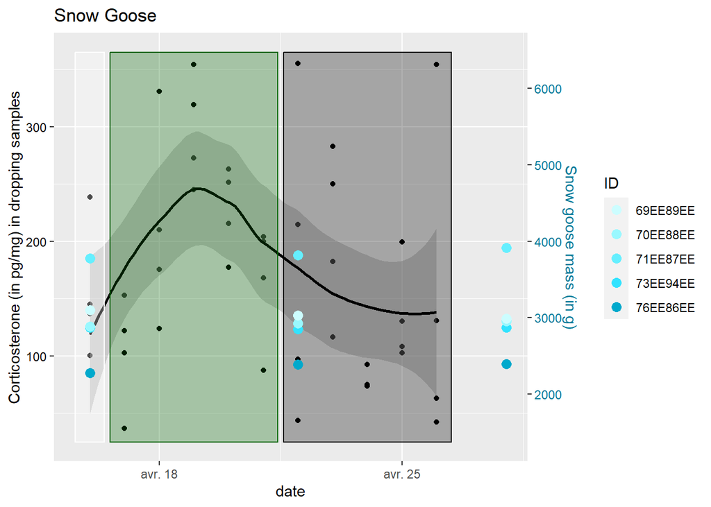

```r
plot_sngo
```

Corticosterone content in droppings and fattening pattern for Canada goose and greater snow goose during experiment at Zoo sauvage de St-Félicien in 2022. Phases of the experiment are represented by the shaded area: white being the recuperation phase, green the experimental treatment and black the control.

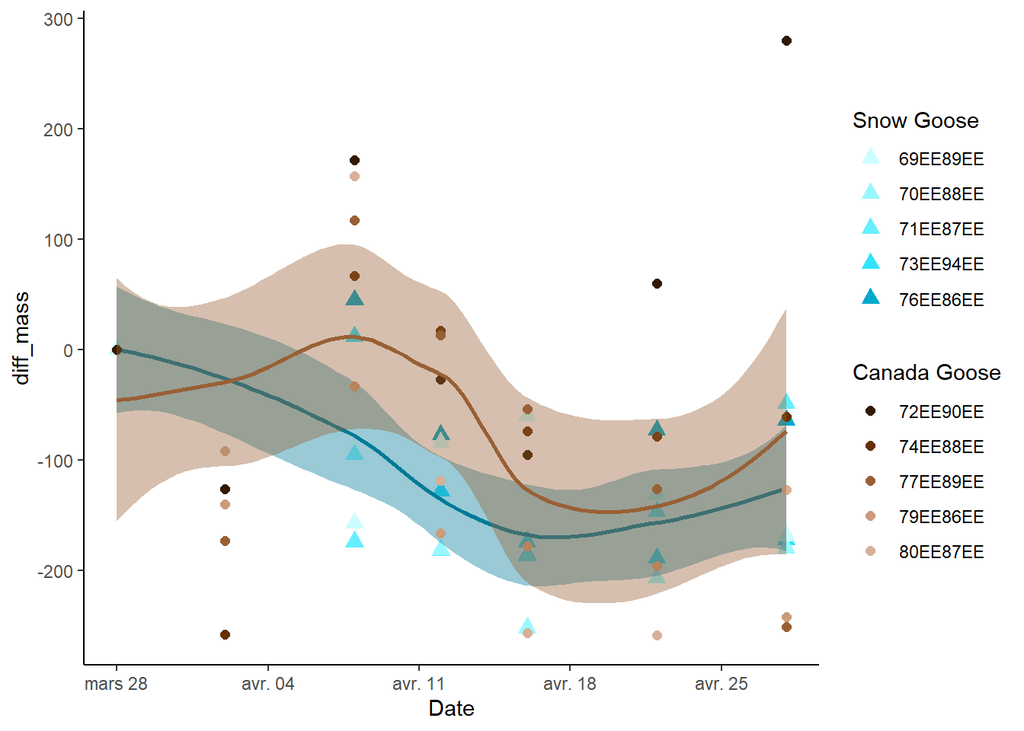

```r
#Différence de masse en fonction de la date
ggplot()+
  # annotate("rect", xmin = as.POSIXct("2022-04-01 10:00:00.00"), xmax = as.POSIXct("2022-04-12 06:00:00.00"), ymin = -275, ymax = 300,  colour="#996035FF",  fill = "#996035FF", alpha=.3) +
  # annotate("rect", xmin = as.POSIXct("2022-04-15 10:00:00.00"), xmax = as.POSIXct("2022-04-26 06:00:00.00"), ymin = -275, ymax = 300,  colour="#007A99FF",  fill = "#007A99FF", alpha=.3)+
  geom_point(data=subset(zoo, Sp=="SNGO"), aes(Date, diff_mass, colour=ID), shape=17, size=3)+
  geom_smooth(data=subset(zoo, Sp=="SNGO"), aes(Date, diff_mass), color="#007A99FF", fill="#007A99FF")+
  scale_color_manual(values=c(col_sngo), name="Snow Goose")+
  new_scale_color()+
  geom_point(data=subset(zoo, Sp=="CAGO"), aes(Date, diff_mass, colour=ID), shape=16, size=2)+
  geom_smooth(data=subset(zoo, Sp=="CAGO"), aes(Date, diff_mass), color="#996035FF", fill= "#996035FF")+
  scale_color_manual(values=c(col_cago), name="Canada Goose")+
  theme_classic()
```

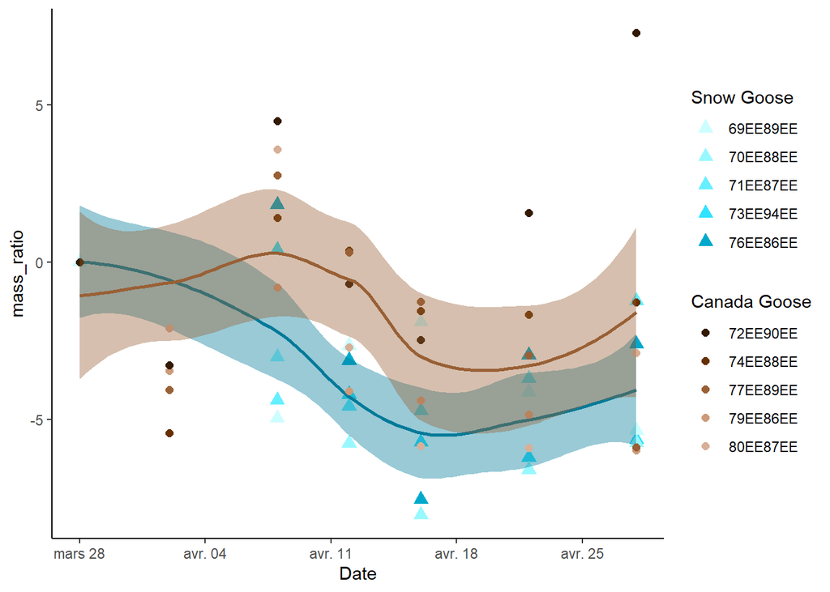

```r
#Ratio de la masse en fonction de la date
ggplot()+
  # annotate("rect", xmin = as.POSIXct("2022-04-01 10:00:00.00"), xmax = as.POSIXct("2022-04-12 06:00:00.00"), ymin = -275, ymax = 300,  colour="#996035FF",  fill = "#996035FF", alpha=.3) +
  # annotate("rect", xmin = as.POSIXct("2022-04-15 10:00:00.00"), xmax = as.POSIXct("2022-04-26 06:00:00.00"), ymin = -275, ymax = 300,  colour="#007A99FF",  fill = "#007A99FF", alpha=.3)+
  geom_point(data=subset(zoo, Sp=="SNGO"), aes(Date, mass_ratio, colour=ID), shape=17, size=3)+
  geom_smooth(data=subset(zoo, Sp=="SNGO"), aes(Date, mass_ratio), color="#007A99FF", fill="#007A99FF")+
  scale_color_manual(values=c(col_sngo), name="Snow Goose")+
  new_scale_color()+
  geom_point(data=subset(zoo, Sp=="CAGO"), aes(Date, mass_ratio, colour=ID), shape=16, size=2)+
  geom_smooth(data=subset(zoo, Sp=="CAGO"), aes(Date, mass_ratio), color="#996035FF", fill= "#996035FF")+
  scale_color_manual(values=c(col_cago), name="Canada Goose")+
  theme_classic()
```

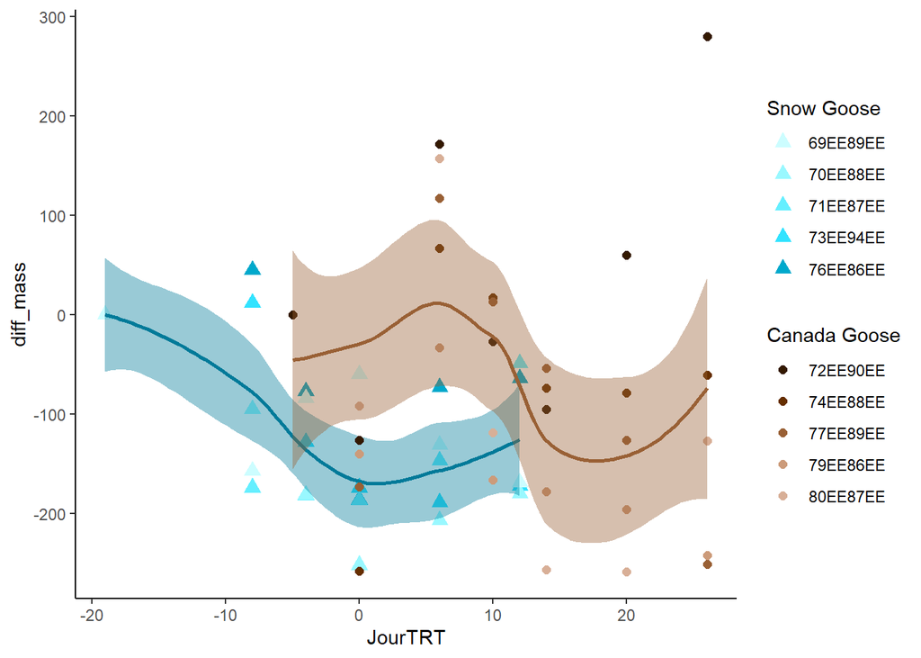

```r
#En fonction du moment du traitement
ggplot()+
  geom_point(data=subset(zoo, Sp=="SNGO"), aes(JourTRT, diff_mass, colour=ID), shape=17, size=3)+
  geom_smooth(data=subset(zoo, Sp=="SNGO"), aes(JourTRT, diff_mass), color="#007A99FF", fill="#007A99FF")+
  scale_color_manual(values=c(col_sngo), name="Snow Goose")+
  new_scale_color()+
  geom_point(data=subset(zoo, Sp=="CAGO"), aes(JourTRT, diff_mass, colour=ID), shape=16, size=2)+
  geom_smooth(data=subset(zoo, Sp=="CAGO"), aes(JourTRT, diff_mass), color="#996035FF", fill= "#996035FF")+
  scale_color_manual(values=c(col_cago), name="Canada Goose")+
  theme_classic()
```

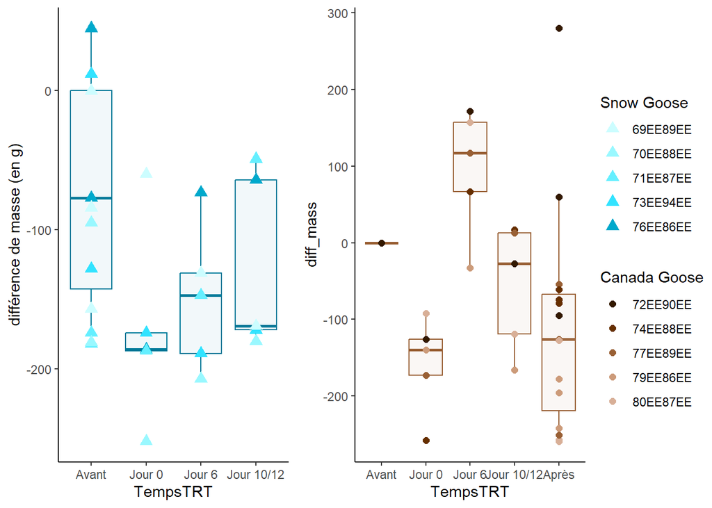

```r
#Différence de masse en fonction du moment du traitement
p1<-ggplot()+
  geom_boxplot(data=subset(zoo, Sp=="SNGO"), aes(TempsTRT, diff_mass), color="#007A99FF", fill="#007A99FF", position= position_dodge(width=0.75), alpha=.05)+
  geom_point(data=subset(zoo, Sp=="SNGO"), aes(TempsTRT, diff_mass, colour=ID), shape=17, size=3)+
  scale_color_manual(values=c(col_sngo), name="Snow Goose")+
  labs(x = "TempsTRT", y = "différence de masse (en g)") +
  theme_classic()
p2<-ggplot()+
  geom_boxplot(data=subset(zoo, Sp=="CAGO"), aes(TempsTRT, diff_mass), color="#996035FF", fill="#996035FF", position= position_dodge(width=0.75), alpha=.05)+
  geom_point(data=subset(zoo, Sp=="CAGO"), aes(TempsTRT, diff_mass, colour=ID), shape=16, size=2)+
    scale_color_manual(values=c(col_cago), name="Canada Goose")+
  theme_classic()
p3<-ggplot()+geom_point(data=subset(zoo, Sp=="SNGO"), aes(TempsTRT, diff_mass, colour=ID), shape=17, size=3)+scale_color_manual(values=c(col_sngo), name="Snow Goose")+new_scale_color()+geom_point(data=subset(zoo, Sp=="CAGO"), aes(TempsTRT, diff_mass, colour=ID), shape=16, size=2)+scale_color_manual(values=c(col_cago), name="Canada Goose")+ theme_classic()
plot_grid(p1 + theme(legend.position = "none"), p2+ theme(legend.position = "none"), get_legend(p3), ncol=3, rel_widths = c(5,5,2))
```

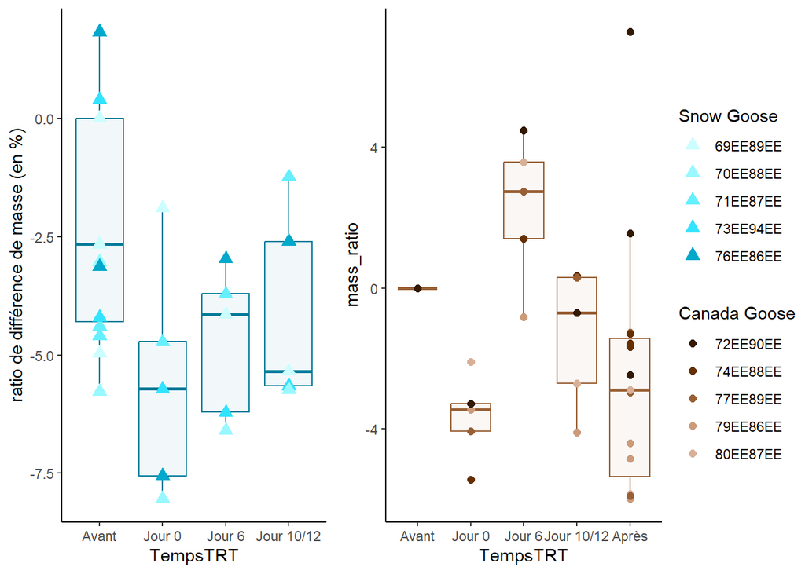

```r
#Ratio en fonction du traitement
p4<-ggplot()+
  geom_boxplot(data=subset(zoo, Sp=="SNGO"), aes(TempsTRT, mass_ratio), color="#007A99FF", fill="#007A99FF", position= position_dodge(width=0.75), alpha=.05)+
  geom_point(data=subset(zoo, Sp=="SNGO"), aes(TempsTRT, mass_ratio, colour=ID), shape=17, size=3)+
  scale_color_manual(values=c(col_sngo), name="Snow Goose")+
  labs(x = "TempsTRT", y = "ratio de différence de masse (en %)") +
  theme_classic()
p5<-ggplot()+
  geom_boxplot(data=subset(zoo, Sp=="CAGO"), aes(TempsTRT, mass_ratio), color="#996035FF", fill="#996035FF", position= position_dodge(width=0.75), alpha=.05)+
  geom_point(data=subset(zoo, Sp=="CAGO"), aes(TempsTRT, mass_ratio, colour=ID), shape=16, size=2)+
    scale_color_manual(values=c(col_cago), name="Canada Goose")+
  theme_classic()
plot_grid(p4 + theme(legend.position = "none"), p5+ theme(legend.position = "none"), get_legend(p3), ncol=3, rel_widths = c(5,5,2))
```

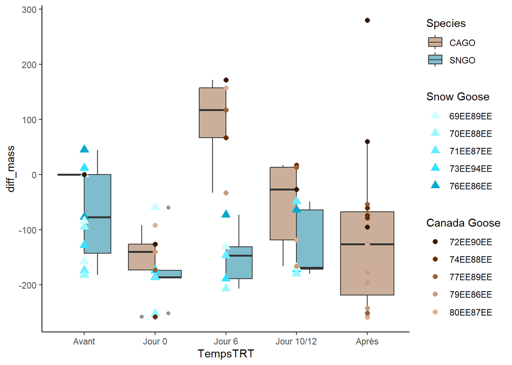

```r
ggplot() +
  geom_boxplot(data = zoo, aes(x = TempsTRT, y = diff_mass, fill = Sp), position = position_dodge(width = 0.75), alpha=0.5) +
  scale_fill_manual(values = c(SNGO = "#007A99FF", CAGO = "#996035FF"), name = "Species") +
  geom_point(data=subset(zoo, Sp=="SNGO"), aes(TempsTRT, diff_mass, colour=ID), shape=17, size=3) +
  scale_color_manual(values=c(col_sngo), name="Snow Goose")+
  new_scale_color()+
  geom_point(data=subset(zoo, Sp=="CAGO"), aes(TempsTRT, diff_mass, colour=ID), shape=16, size=2)+
  scale_color_manual(values=c(col_cago), name="Canada Goose")+
  theme_classic()
```

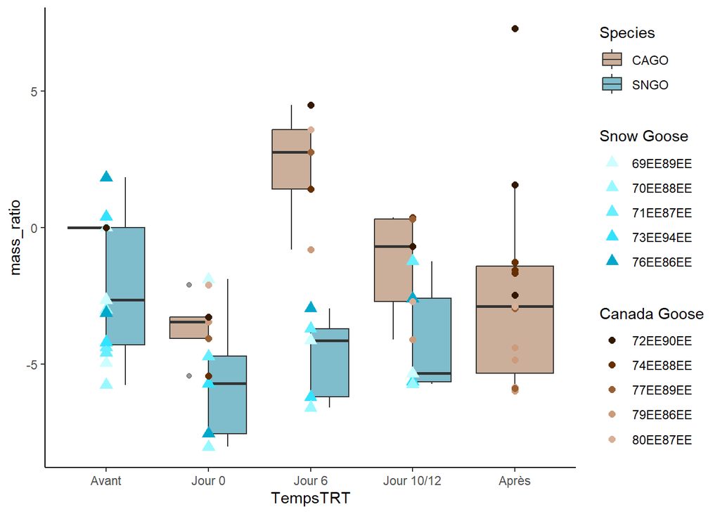

```r
ggplot() +
  geom_boxplot(data = zoo, aes(x = TempsTRT, y = mass_ratio, fill = Sp), position = position_dodge(width = 0.75), alpha=0.5) +
  scale_fill_manual(values = c(SNGO = "#007A99FF", CAGO = "#996035FF"), name = "Species") +
  geom_point(data=subset(zoo, Sp=="SNGO"), aes(TempsTRT, mass_ratio, colour=ID), shape=17, size=3) +
  scale_color_manual(values=c(col_sngo), name="Snow Goose")+
  new_scale_color()+
  geom_point(data=subset(zoo, Sp=="CAGO"), aes(TempsTRT, mass_ratio, colour=ID), shape=16, size=2)+
  scale_color_manual(values=c(col_cago), name="Canada Goose")+
  theme_classic()
```

We can already see that the change in mass pattern seems to be more influenced by the date (seasonal changes) than by the treatment.